# Freight management(Shipment Cost Prediction)

## IS_HAZARDOUS vs ORDER COST

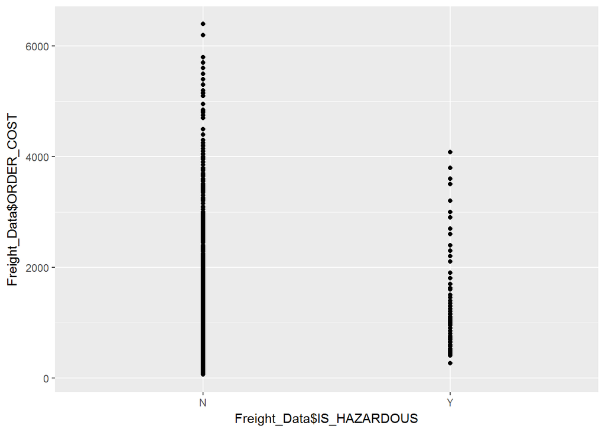

```r
ggplot(Freight_Data, aes(x= Freight_Data$IS_HAZARDOUS, y=Freight_Data$ORDER_COST)) + geom_point()
```

```r
# The plot shows order cost is more for Non Harzardous
```

## Equipment Type vs Order Cost

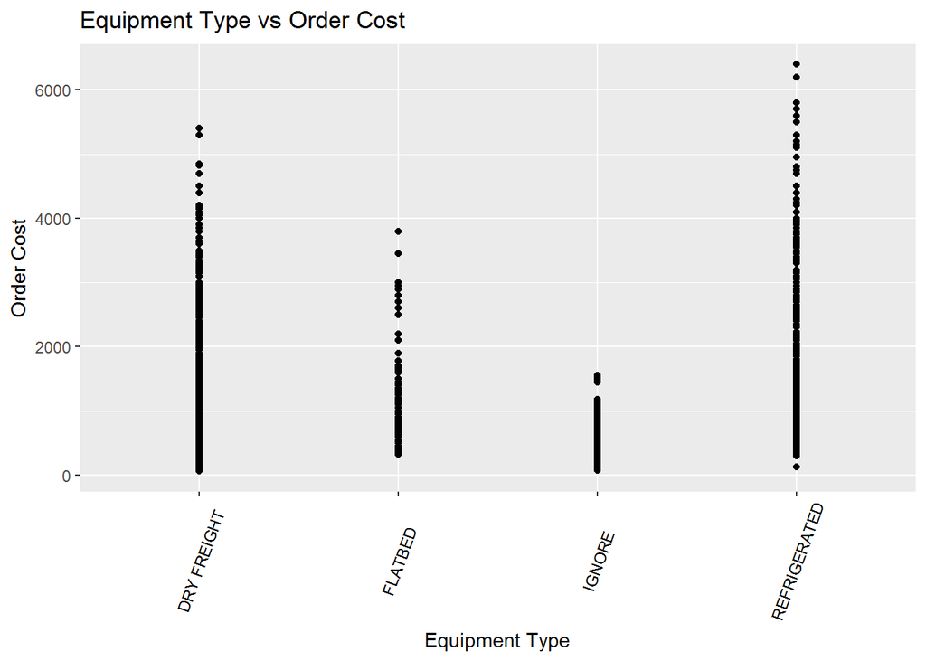

```r
ggplot(Freight_Data, aes(x=EQUIP_TYPE, y=ORDER_COST)) +
  geom_point() +
  theme(axis.text.x = element_text(angle = 70, vjust = 0.5, color = "black"))+
  xlab("Equipment Type") +
  ylab("Order Cost") +
  ggtitle("Equipment Type vs Order Cost")
```

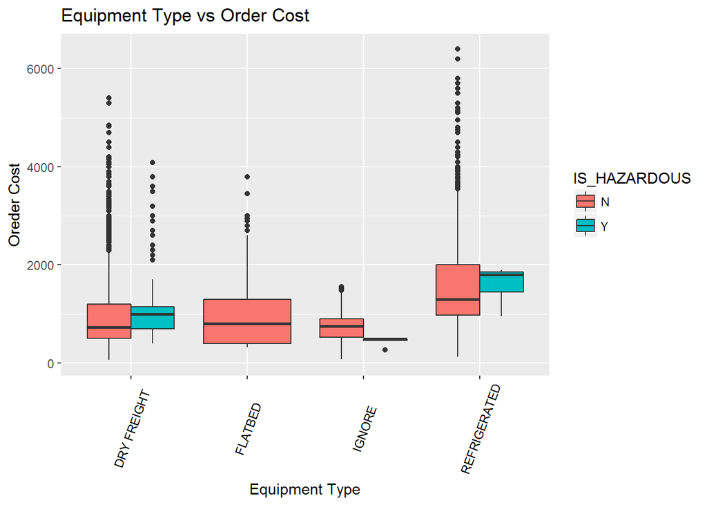

```r
ggplot(Freight_Data, aes(x= EQUIP_TYPE, y=ORDER_COST, fill= IS_HAZARDOUS)) +
  geom_boxplot() +
  theme(axis.text.x = element_text(angle = 70, vjust = 0.5, color = "black"))+
  xlab("Equipment Type") +
  ylab("Oreder Cost") +
  ggtitle("Equipment Type vs Order Cost")
```

```r
# The above plot shows that the "R" refrigerated will have more shipment cost
```

Data Cleaning

# Remove the NA’s and Spaces

```r
sum(is.na(Freight_Data))
```

```
## [1] 1579
```

```r
Freight_Data<-na.omit(Freight_Data)
```

Feature Engineering

## 1)

```r
# Create a new variable DELIVERY_DAY (Number od days required for shipping the goods)
# by subtracting (LAST_DELIVERY_EARLY_APPT - FIRST_PICK_EARLY_APPT), Convert both the dates into
# Julian dates and then subtract

Temp_Pick_Date <- as.Date(Freight_Data$FIRST_PICK_EARLY_APPT,format="%m-%d-%Y")
Temp_Delivery_Date <- as.Date(Freight_Data$LAST_DELIVERY_EARLY_APPT,format="%m-%d-%Y")

Freight_Data$PICK_DAY_JULIAN <- as.numeric(format(Temp_Pick_Date, "%j"))
Freight_Data$DELIVERY_DAY_JULIAN = as.numeric (format(Temp_Delivery_Date,"%j"))

Freight_Data$DELIVERY_DAY <- Freight_Data$DELIVERY_DAY_JULIAN - Freight_Data$PICK_DAY_JULIAN

# Replace the Negative and greater than 15 DELIVERY_TIME values to Zero(0)

Freight_Data$DELIVERY_DAY[Freight_Data$DELIVERY_DAY < 0] <- 0
Freight_Data$DELIVERY_DAY[Freight_Data$DELIVERY_DAY > 15] <- 0

rm(Temp_Pick_Date,Temp_Delivery_Date)
```

## 2)

```r
# Create a new variable DELIVERY_TIME by subtracting
# (LAST_DELIVERY_EARLY_APPT - FIRST_PICK_EARLY_APPT), Convert both the dates and time into
# Hours and then subtract

Freight_Data$PICKUP_TIME_TEMP <- as.POSIXct(Freight_Data$FIRST_PICK_EARLY_APPT,format='%m-%d-%Y %H:%M')
Freight_Data$DELIVERY_TIME_TEMP <- as.POSIXct(Freight_Data$LAST_DELIVERY_EARLY_APPT,format='%m-%d-%Y %H:%M')

Freight_Data$DELIVERY_TIME <- ceiling((Freight_Data$DELIVERY_TIME_TEMP - Freight_Data$PICKUP_TIME_TEMP)/3600)
Freight_Data$DELIVERY_TIME <- as.numeric(Freight_Data$DELIVERY_TIME)
Freight_Data$DELIVERY_TIME[Freight_Data$DELIVERY_TIME < 0] <- 0
Freight_Data$DELIVERY_TIME[Freight_Data$DELIVERY_TIME > 360] <- 0
```

## 3)

```r
# convert CREATED_DATE to DAY and MONTH to check the trends in orders.

Freight_Data$CREATED_DAY <- weekdays(as.Date(Freight_Data$CREATED_DATE,format="%m-%d-%Y"))
Freight_Data$CREATED_MONTH <- months(as.Date(Freight_Data$CREATED_DATE,format="%m-%d-%Y"))
```

## 4)

```r
# Covert the FIRST_PICKUP_ZIP into Area and Market. Do the lookup based on first
# three char into region and market file/dataset.

# Subsrting the FIRST_PICK_ZIP TO FIRST 3 char to compare
# with market & region codes

Freight_Data$PICK_ZIP <- substr(Freight_Data$FIRST_PICK_ZIP,1,3)

# Do the lookup using Merge function

Freight_Data <- merge(x=Freight_Data, y=Region_Pick_Lookup_Data, by.x="PICK_ZIP", by.y="ZIPCODE")
Freight_Data <- merge(x=Freight_Data, y=Market_Pick_Lookup_Data, by.x="PICK_ZIP", by.y="ZIPS")
```

## 5)

```r
# Covert the LAST_DELIVERY_ZIP into Area and Market. Do the lookup based on first
# 3 char into region and market file/dataset.

# Subsrting the LAST_DELIVERY_ZIP TO FIRST 3 char to compare
# with market & region codes

Freight_Data$DELIVERY_ZIP <- substr(Freight_Data$LAST_DELIVERY_ZIP,1,3)

# Do the lookup using Merge function

Freight_Data <- merge(x=Freight_Data, y=Region_Delivery_Lookup_Data, by.x="DELIVERY_ZIP", by.y="ZIPCODE")
Freight_Data <- merge(x=Freight_Data, y=Market_Delivery_Lookup_Data, by.x="DELIVERY_ZIP", by.y="ZIPS")
```

## 6)

```r
# Generate the new column from PICKUP_MARKET and DELIVERY_MARKET

Freight_Data$PICK_DEL_MARKET <- paste(Freight_Data$PICKUP_MARKET,'->',Freight_Data$DELIVERY_MARKET)
Freight_Data <- merge(Freight_Data, data.frame(table(PICK_DEL_MARKET = Freight_Data$PICK_DEL_MARKET)), by = c("PICK_DEL_MARKET"))

# Reduce the Levels

Freight_Data$PICK_DEL_MARKET <- ifelse(Freight_Data$Freq < 100,"OTHER -> OTHER",Freight_Data$PICK_DEL_MARKET)
Freight_Data$PICK_DEL_MARKET <- as.factor(Freight_Data$PICK_DEL_MARKET)
Freight_Data$Freq <- NULL
```

## 7)

```r
# Generate the new column from PICKUP_REGION and DELIVERY_REGION

Freight_Data$PICK_DEL_REGION <- paste(Freight_Data$PICKUP_REGION,'->',Freight_Data$DELIVERY_REGION)

Freight_Data <- merge(Freight_Data, data.frame(table(PICK_DEL_REGION = Freight_Data$PICK_DEL_REGION)), by = c("PICK_DEL_REGION"))
# Reduce the Levels

Freight_Data$PICK_DEL_REGION <- ifelse(Freight_Data$Freq < 200,"REGOTHER - REGOTHER",Freight_Data$PICK_DEL_REGION)
Freight_Data$PICK_DEL_REGION <- as.factor(Freight_Data$PICK_DEL_REGION)
```

Remove the unwanted Varibales

## Remove the attributes from dataset which will not have any contributions

```r
Freight_Data$FIRST_PICK_ZIP <- NULL
Freight_Data$FIRST_PICK_LATE_APPT <- NULL
Freight_Data$LAST_DELIVERY_ZIP <- NULL
Freight_Data$LAST_DELIVERY_LATE_APPT <- NULL
Freight_Data$FIRST_PICK_EARLY_APPT <- NULL
Freight_Data$LAST_DELIVERY_EARLY_APPT <- NULL
Freight_Data$PICK_DAY_JULIAN <- NULL
Freight_Data$DELIVERY_DAY_JULIAN <- NULL
Freight_Data$CREATED_DATE <- NULL
Freight_Data$DELIVERY_ZIP <- NULL
Freight_Data$PICK_ZIP <- NULL
Freight_Data$FIRST_PICK_ZIP <- NULL
Freight_Data$LAST_DELIVERY_ZIP <- NULL
Freight_Data$PICKUP_TIME_TEMP <- NULL
Freight_Data$DELIVERY_TIME_TEMP <- NULL
Freight_Data$NEW_ABBR <- NULL
Freight_Data$EQUIPMENT_TYPE <- NULL
Freight_Data$Freq <- NULL
Freight_Data$PICKUP_REGION <- NULL
Freight_Data$DELIVERY_REGION <- NULL
Freight_Data$PICKUP_MARKET <- NULL
Freight_Data$DELIVERY_MARKET <- NULL
Freight_Data$DELIVERY_TIME <- NULL

# Convert to proper format (Numeric/Factor)

Freight_Data$CREATED_DAY <- as.factor(Freight_Data$CREATED_DAY)
Freight_Data$CREATED_MONTH <- as.factor(Freight_Data$CREATED_MONTH)
Freight_Data$CUSTOMER_MILES <- as.numeric(Freight_Data$CUSTOMER_MILES)
Freight_Data$WEIGHT <- as.numeric(Freight_Data$WEIGHT)

# Summary

str(Freight_Data)
```

```
## 'data.frame':    23679 obs. of  11 variables:
##  $ PICK_DEL_REGION: Factor w/ 31 levels "California -> California",..: 1 1 1 1 1 1 1 1 1 1 ...
##  $ PICK_DEL_MARKET: Factor w/ 43 levels "AZ_TUC -> CA_LAX",..: 30 30 30 30 30 30 30 30 30 30 ...
##  $ ORDER_NBR      : int  188289 180929 170944 174374 189817 190424 188422 184445 171894 185279 ...
##  $ CUSTOMER_MILES : num  184 24 99 16 276 359 276 276 24 134 ...
##  $ WEIGHT         : num  31637 37316 11423 11330 37980 ...
##  $ ORDER_COST     : num  625 275 350 275 600 825 600 600 275 950 ...
##  $ IS_HAZARDOUS   : Factor w/ 2 levels "N","Y": 1 1 1 1 1 1 1 1 1 2 ...
##  $ EQUIP_TYPE     : Factor w/ 4 levels "DRY FREIGHT",..: 1 1 1 1 4 1 4 4 1 1 ...
##  $ DELIVERY_DAY   : num  1 0 1 0 1 1 1 1 0 0 ...
##  $ CREATED_DAY    : Factor w/ 7 levels "Friday","Monday",..: 5 6 7 5 1 7 1 1 7 5 ...
##  $ CREATED_MONTH  : Factor w/ 5 levels "April","February",..: 5 4 3 2 5 5 5 1 2 1 ...
```

```r
names(Freight_Data)
```

```
##  [1] "PICK_DEL_REGION" "PICK_DEL_MARKET" "ORDER_NBR"
##  [4] "CUSTOMER_MILES"  "WEIGHT"          "ORDER_COST"
##  [7] "IS_HAZARDOUS"    "EQUIP_TYPE"      "DELIVERY_DAY"
## [10] "CREATED_DAY"     "CREATED_MONTH"
```

##### Remove the duplicates based on order Number(ORDER_NBR)

```r
table(duplicated(Freight_Data$ORDER_NBR))
```

```
##
## FALSE  TRUE
## 16711  6968
```

```r
Freight_Data_No_Dup  <- subset(Freight_Data, !duplicated(Freight_Data[,3]))
```

Final datsets with all pre- proceesing

```r
# Final dataset (Freight_Data_No_Dup)

Freight_Data_No_Dup$ORDER_NBR <- NULL
```

Univariate Analyis for new Variables

## For CREATED_DAY

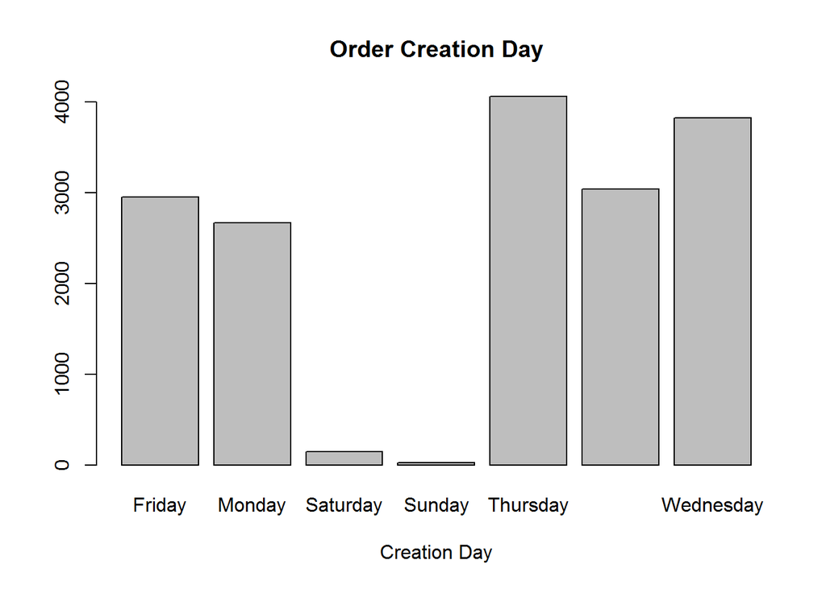

```r
counts <- table(Freight_Data_No_Dup$CREATED_DAY)
barplot(counts, main="Order Creation Day", xlab="Creation Day")
```

```r
# This shows more business on weekdays (Mon, Tue, Wed, Thur, Friday).
# Thursday is the Highest
# Least business on weekend.
```

## For CREATED_MONTH

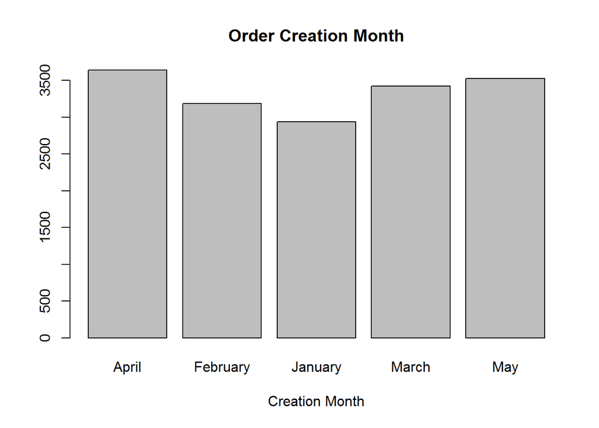

```r
counts <- table(Freight_Data_No_Dup$CREATED_MONTH)
barplot(counts, main="Order Creation Month", xlab="Creation Month")
```

```r
# This shows the APR and MAy month has more business.
```

## For PICKUP_REGION

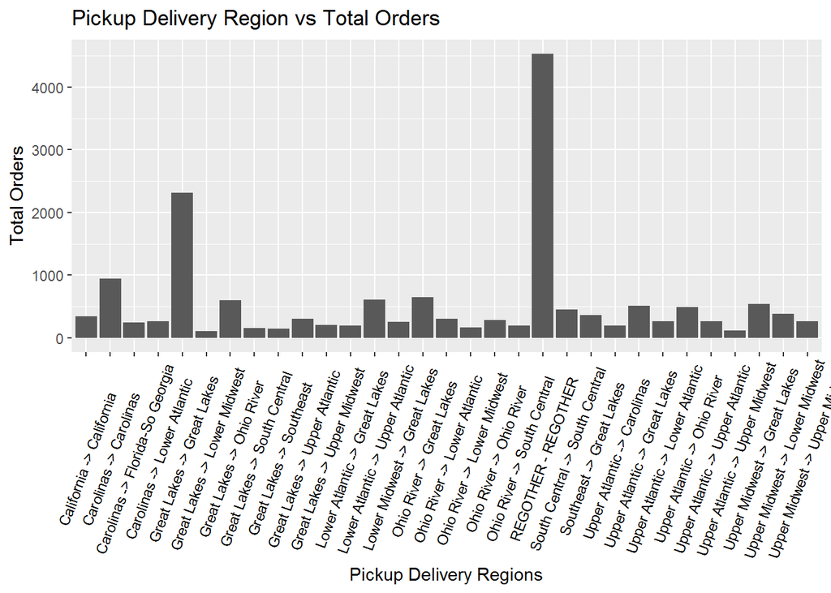

```r
counts <- table(Freight_Data_No_Dup$PICK_DEL_REGION)
ggplot(Freight_Data_No_Dup, aes(x=PICK_DEL_REGION)) +
  geom_bar() +
  theme(axis.text.x = element_text(angle = 70, vjust = 0.5, color = "black"))+
  xlab("Pickup Delivery Regions") +
  ylab("Total Orders") +
  ggtitle("Pickup Delivery Region vs Total Orders")
```

# For Market

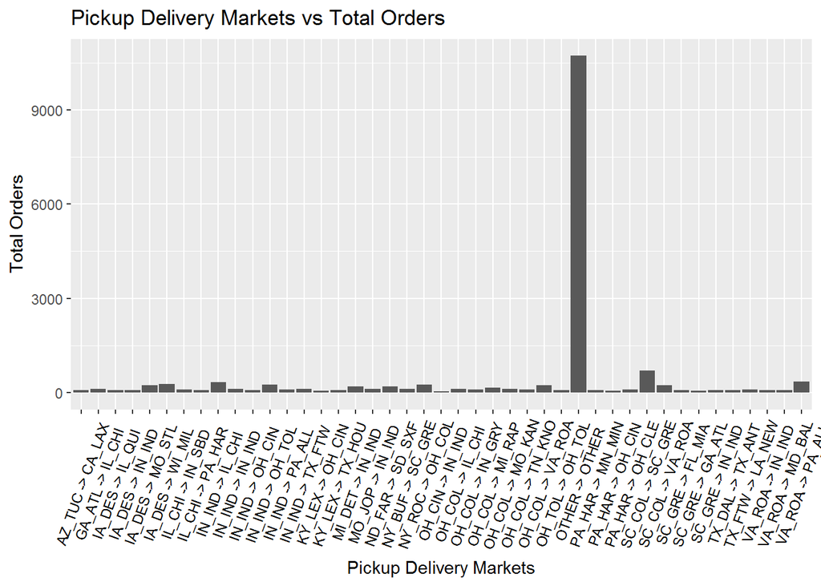

```r
counts <- table(Freight_Data_No_Dup$PICK_DEL_MARKET)

ggplot(Freight_Data_No_Dup, aes(x=PICK_DEL_MARKET)) +
  geom_bar() +
  theme(axis.text.x = element_text(angle = 70, vjust = 0.5, color = "black"))+
  xlab("Pickup Delivery Markets") +
  ylab("Total Orders") +
  ggtitle("Pickup Delivery Markets vs Total Orders")
```

## For DELIVERY_DAY

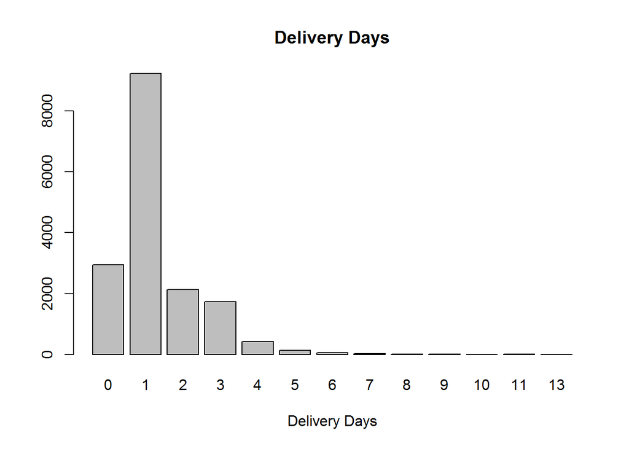

```r
counts <- table(Freight_Data_No_Dup$DELIVERY_DAY)
barplot(counts, main="Delivery Days", xlab="Delivery Days")
```

```r
# One day(1) deliveries is the heighst, then comes the same day(0) deliveries
```

Bi Varaite Analysis

## Analysis for DELIVERY_DAY & ORDER_COST

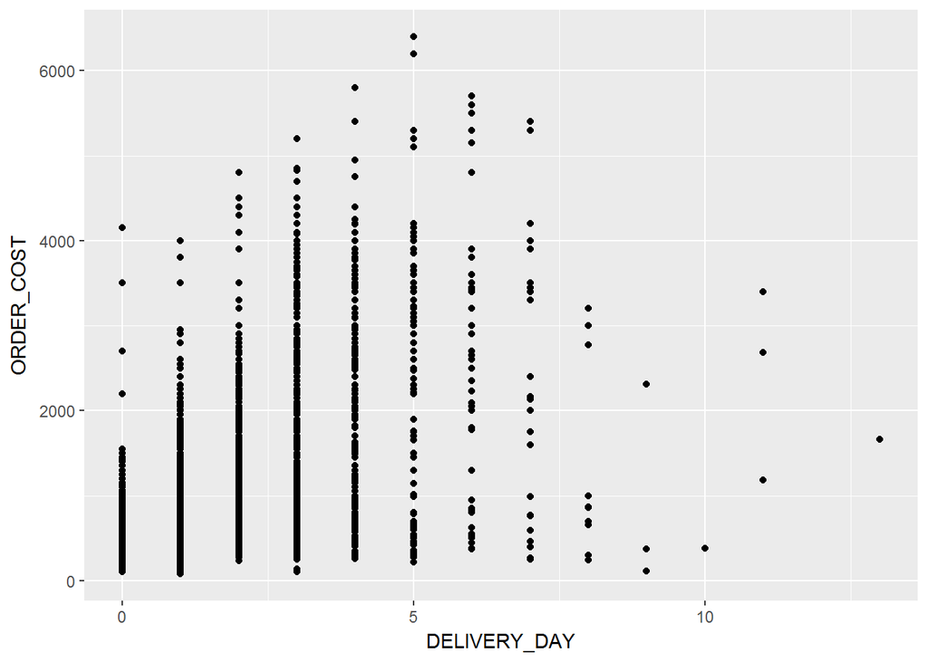

```r
ggplot(Freight_Data_No_Dup, aes(x= DELIVERY_DAY, y=ORDER_COST)) + geom_point()
```

```r
cor(Freight_Data$DELIVERY_DAY,Freight_Data$ORDER_COST)
```

```
## [1] 0.5988138
```

## Plot for PICK_DEL_REGION & ORDER_COST

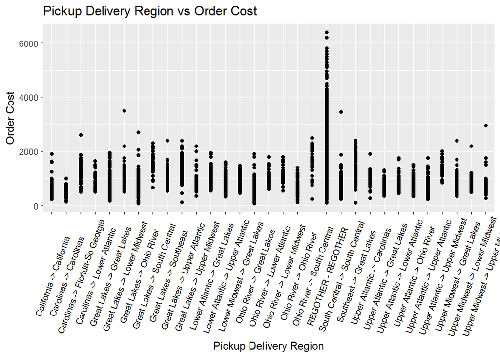

```r
ggplot(Freight_Data_No_Dup, aes(x= PICK_DEL_REGION, y=ORDER_COST)) +
  geom_point() +
  theme(axis.text.x = element_text(angle = 70, vjust = 0.5, color = "black"))+
  xlab("Pickup Delivery Region") +
  ylab("Order Cost") +
  ggtitle("Pickup Delivery Region vs Order Cost")
```

## Plot for PICK_DEL_MARKET & ORDER_COST

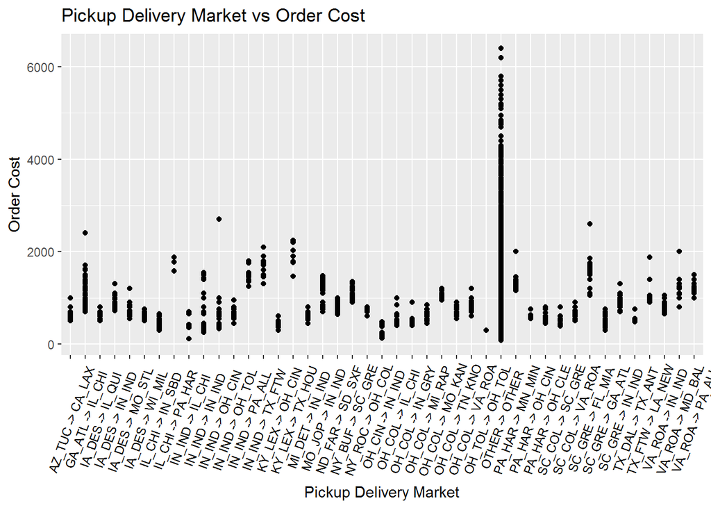

```r
ggplot(Freight_Data_No_Dup, aes(x= PICK_DEL_MARKET, y=ORDER_COST)) +
  geom_point() +
  theme(axis.text.x = element_text(angle = 70, vjust = 0.5, color = "black"))+
  xlab("Pickup Delivery Market") +
  ylab("Order Cost") +
  ggtitle("Pickup Delivery Market vs Order Cost")
```

Re-Arrange the variables

## Re arrange the Numeric and categorical attributes

```r
# Categorical Variables

Fac_Col_Names = c("EQUIP_TYPE", "IS_HAZARDOUS", "CREATED_DAY", "CREATED_MONTH",
                  "PICK_DEL_REGION", "PICK_DEL_MARKET")
# Numeric Vraibles

Num_Col_Names = c("WEIGHT","CUSTOMER_MILES","DELIVERY_DAY")

# Prepare for Clustering

Freight_Data_No_Dup_Clust <- Freight_Data_No_Dup

# Keeping only "WEIGHT","CUSTOMER_MILES","DELIVERY_DAY" varibales in dataset

Freight_Data_Clust <- Freight_Data_No_Dup[,Num_Col_Names]

# Categorizing cat, num and taget varibales

Freight_Data_F = Freight_Data_No_Dup[,Fac_Col_Names]
Freight_Data_N = Freight_Data_No_Dup[,Num_Col_Names]
Freight_Data_T = subset(Freight_Data_No_Dup,select="ORDER_COST")

## Converting categorical attributes into DUMMY variables

Freight_Data_Dum_F <- model.matrix(Freight_Data_No_Dup$ORDER_COST ~ Freight_Data_No_Dup$EQUIP_TYPE + Freight_Data_No_Dup$IS_HAZARDOUS +
    Freight_Data_No_Dup$CREATED_DAY + Freight_Data_No_Dup$CREATED_MONTH + Freight_Data_No_Dup$PICK_DEL_REGION + Freight_Data_No_Dup$PICK_DEL_MARKET)[,-1]

## Final dataset with dummy

Freight_Data_No_Dup <- cbind(Freight_Data_N,Freight_Data_Dum_F,Freight_Data_T)
```

## Split into Train and Test (70:30)

```r
rows<-seq(1,nrow(Freight_Data_No_Dup),1)
set.seed(1234)
trainrows<-sample(rows,0.7*nrow(Freight_Data_No_Dup))

Train <- data.frame(Freight_Data_N,Freight_Data_Dum_F,ORDER_COST=Freight_Data_No_Dup$ORDER_COST)[trainrows,]
Test <- data.frame(Freight_Data_N,Freight_Data_Dum_F,ORDER_COST=Freight_Data_No_Dup$ORDER_COST)[-trainrows,]
```

Model Building

## First Apply the Random Forest to know the important Variables

```r
## Random Forest using h2O

library(h2o)

## h2o.init functions connect to H2O
## Starts H2O using localhost IP, port 54321, all CPUs, and 4g of memory
## h2o.init(ip = "localhost", port = 54321, nthreads= -1, max_mem_size = "4g")

h2o.init(ip='localhost', port = 54321, max_mem_size = '4g')
```

[output not shown]

```r
## Converts R object into H2O object "Train.hex"

Train.hex <- as.h2o(x = Train, destination_frame = "Train.hex")
y = "ORDER_COST"
x = setdiff(colnames(Train.hex), y)

## Build the Random Forest with 500 Trees

rf_mod <- h2o.randomForest(x, y, Train.hex, ntrees = 500)
## Summary

summary(rf_mod)
```

```
## Model Details:
## ==============
##
## H2ORegressionModel: drf
## Model Key:  DRF_model_R_1481282457065_1
## Model Summary:
##   number_of_trees number_of_internal_trees model_size_in_bytes min_depth
## 1             500                      500            17085892        20
##   max_depth mean_depth min_leaves max_leaves mean_leaves
## 1        20   20.00000       1837       3360  2703.75000
##
## H2ORegressionMetrics: drf
## ** Reported on training data. **
## ** Metrics reported on Out-Of-Bag training samples **
##
## MSE:  27226.19
## RMSE:  165.0036
## MAE:  82.36396
## RMSLE:  0.1400325
## Mean Residual Deviance :  27226.19
##
##
##
##
##
## Scoring History:
##             timestamp   duration number_of_trees training_rmse
## 1 2016-12-09 16:51:05  0.316 sec               0
## 2 2016-12-09 16:51:06  0.933 sec               1     227.24453
## 3 2016-12-09 16:51:06  1.194 sec               2     228.48124
## 4 2016-12-09 16:51:06  1.397 sec               3     226.50847
## 5 2016-12-09 16:51:06  1.556 sec               4     217.60766
##   training_mae training_deviance
## 1
## 2    106.41205       51640.07749
## 3    107.42920       52203.67527
## 4    106.63700       51306.08630
## 5    104.37598       47353.09504
##
## ---
```

[output cut: 32 more lines]

```
## ---
##                                               variable relative_importance
## 84 Freight_Data_No_Dup.PICK_DEL_MARKETPA_HAR....OH_CLE      9852850.000000
## 85 Freight_Data_No_Dup.PICK_DEL_MARKETOH_COL....IL_CHI      9269169.000000
## 86 Freight_Data_No_Dup.PICK_DEL_MARKETTX_DAL....TX_ANT      9012970.000000
## 87 Freight_Data_No_Dup.PICK_DEL_MARKETOH_COL....IN_GRY      7694445.500000
## 88 Freight_Data_No_Dup.PICK_DEL_MARKETOH_COL....MI_RAP      7342620.000000
## 89 Freight_Data_No_Dup.PICK_DEL_MARKETKY_LEX....OH_CIN      5883466.000000
##    scaled_importance percentage
## 84          0.000008   0.000005
## 85          0.000008   0.000005
## 86          0.000007   0.000005
## 87          0.000006   0.000004
## 88          0.000006   0.000004
## 89          0.000005   0.000003
```

```r
h2o.removeAll()
```

```
## [1] 0
```

```r
h2o.shutdown(prompt = F)
```

```
## [1] TRUE
```

Model (1)

## Baseline model

```r
# Baseline model is the one which requires no predictive model and its like an informed guess.
# For instance, in this case lets predict the shipment cost as overall average of ORDER_COST.

summary(Freight_Data$ORDER_COST)
```

```
##    Min. 1st Qu.  Median    Mean 3rd Qu.    Max.
##      78     550     750    1019    1250    6400
```

```r
# Mean = 1019
```

Model (2)

## Linear Regression

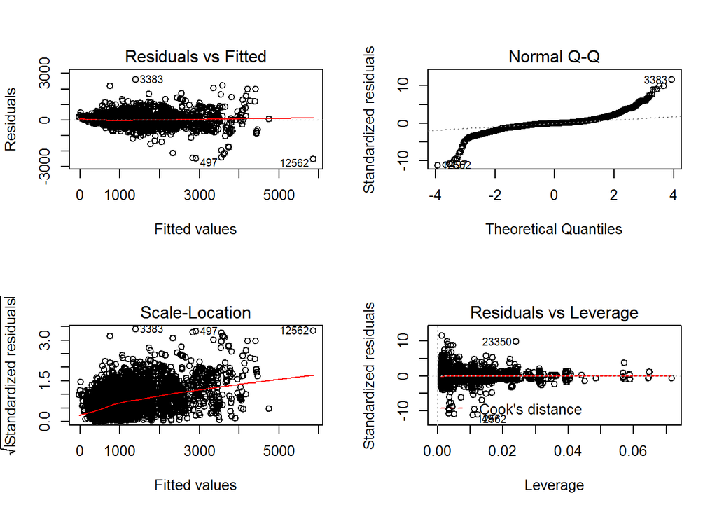

```r
Linreg <- lm(ORDER_COST ~ .,data=Train)
#summary(Linreg)
## Results
# Multiple R-squared:  0.8896, Adjusted R-squared:  0.8888
# F-statistic:  1051 on 89 and 11607 DF,  p-value: < 2.2e-16


# Check for Multicolinarity, All are less than 10
#vif(Linreg)

# Plot

par(mfrow=c(2,2))
plot(Linreg)
```

```r
## Error metrics evaluation on train data

library(DMwR)
train_Lm <- regr.eval(Train$ORDER_COST, predict(Linreg,Train))
train_Lm
```

```
##          mae          mse         rmse         mape
## 1.316923e+02 5.020059e+04 2.240549e+02 1.471939e-01
```

```r
## Error verification on test data

test_Lm <- regr.eval(Test$ORDER_COST, predict(Linreg,Test))
test_Lm
```

```
##          mae          mse         rmse         mape
## 1.370007e+02 5.553791e+04 2.356648e+02 1.491166e-01
```

# The difference between the mean absolute percentage error in train and test

# is not much. So the model seems to be good.

Prepare the data for GLM models

```r
## Converted the data into matrix form for input

Freight_Data_glm <- as.matrix(data.frame(Freight_Data_N,Freight_Data_Dum_F))

## Split the data into Train and Test for GLM

Train_glm = Freight_Data_glm[trainrows,]
Test_glm = Freight_Data_glm[-trainrows,]

## Take out the Target Varaible

y_train = Freight_Data_No_Dup$ORDER_COST[trainrows]
y_test = Freight_Data_No_Dup$ORDER_COST[-trainrows]
```

Model (3)

## Lasso Regression using glmnet - L1 norm (Least Absolute Shrinkage and Selection Operator)

```r
# LASSO creates a regression model that is penalized with the L1-norm
# which is the sum of the absolute coefficients. This has the effect of
# shrinking coefficient values (and the complexity of the model),allowing some
# with a minor effect to the response to become zero.

library(glmnet)
```

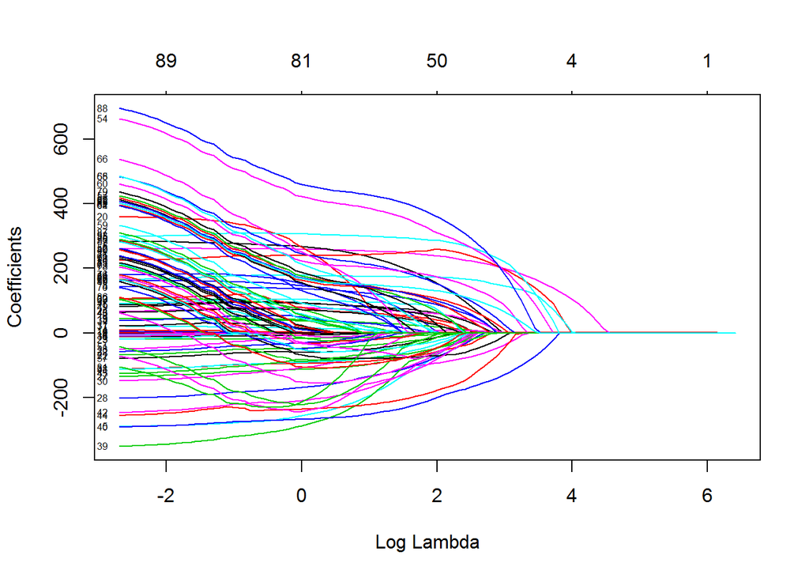

```r
library(DMwR)

## Fit Model

fit1 <- glmnet(Train_glm, y_train, alpha=1)

## Plots

plot(fit1,xvar="lambda", label=TRUE)
```

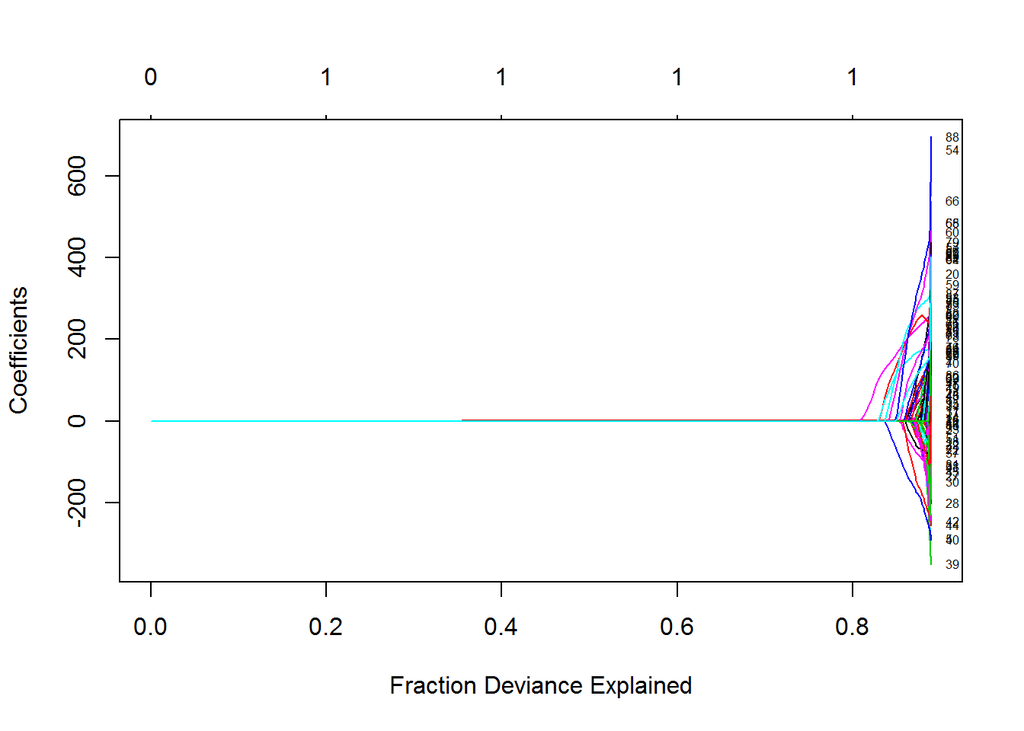

```r
plot(fit1,xvar="dev", label=TRUE)
```

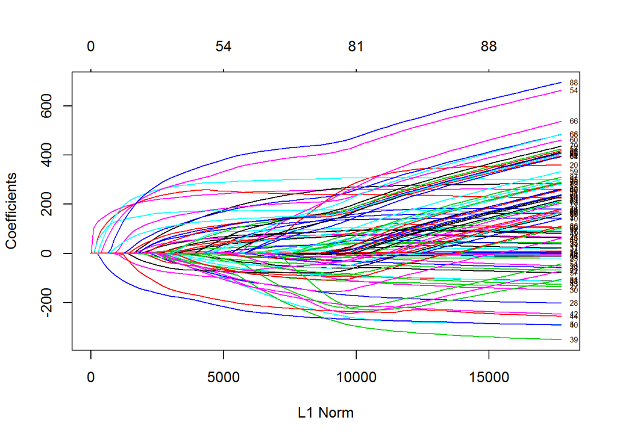

```r
plot(fit1,xvar="norm", label=TRUE)
```

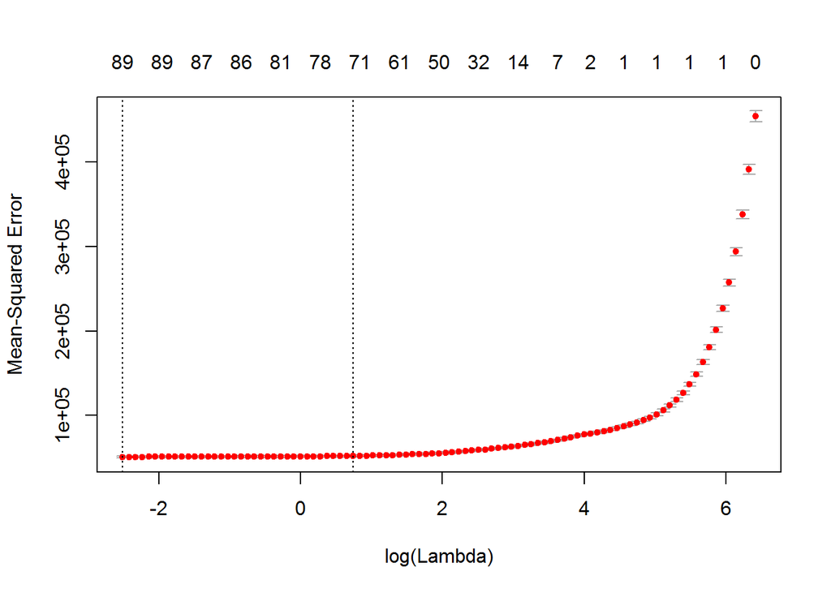

```r
## Model Selection

cv.lasso=cv.glmnet(Train_glm, y_train)

## Plot

plot(cv.lasso)
```

```r
#coef(cv.lasso)
#cv.lasso$cvm

## lambda.min - value of lambda that gives minimum cvm - mean cross-validated error
cv.lasso$lambda.min
```

```
## [1] 0.08112347
```

```r
## Predict

fit_Lasso = glmnet(Train_glm,y_train,lambda=cv.lasso$lambda.min,alpha=1)

## Error Verification on Train

train_Lasso = regr.eval(y_train, predict(fit_Lasso,Train_glm))
train_Lasso
```

```
##          mae          mse         rmse         mape
## 1.318873e+02 5.023455e+04 2.241307e+02 1.474764e-01
```

```r
## Error Verification on Test
test_Lasso = regr.eval(y_test, predict(fit_Lasso,Test_glm))
test_Lasso
```

```
##         mae         mse        rmse        mape
##   137.11576 55534.84935   235.65833     0.14928
```

Model (4)

## Ridge Regression using glmnet - L2 norm

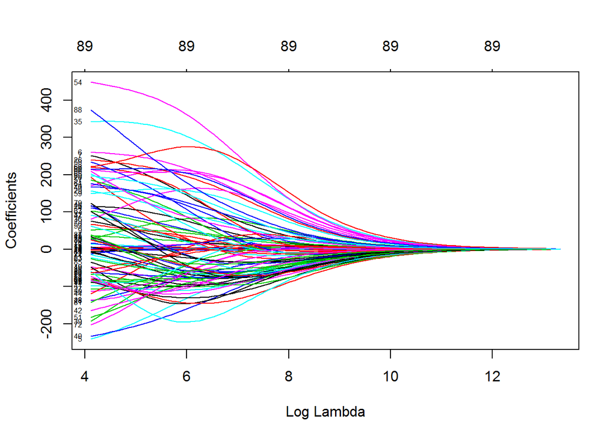

```r
# Ridge Regression creates a linear regression model that is penalized with
# the L2-norm which is the sum of the squared coefficients. This has the effect
# of shrinking the coefficient values (and the complexity of the model) allowing
# some coefficients with minor contribution to the response to get close to zero.

library(glmnet)
library(DMwR)

## fit model

fit2 <- glmnet(Train_glm,y_train,alpha=0)

## Plots

plot(fit2,xvar="lambda",label=TRUE)
```

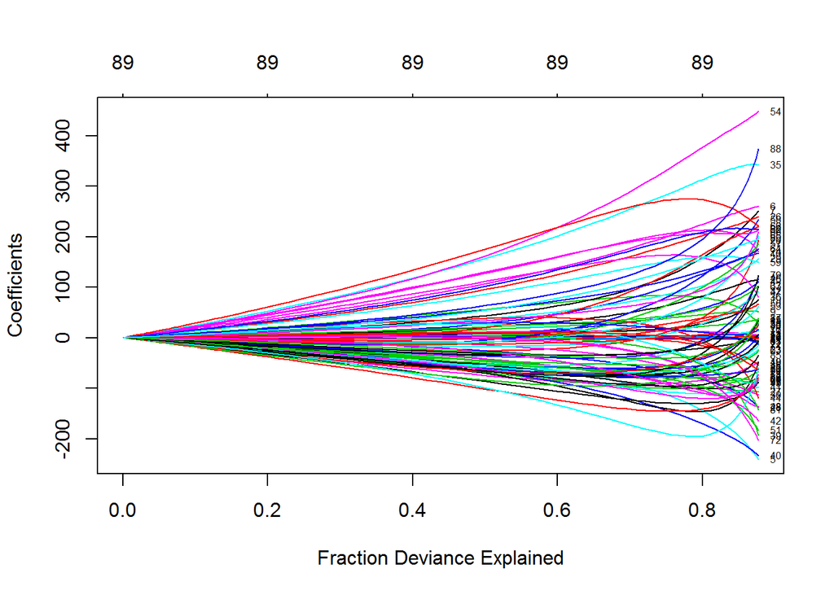

```r
plot(fit2,xvar="dev", label=TRUE)
```

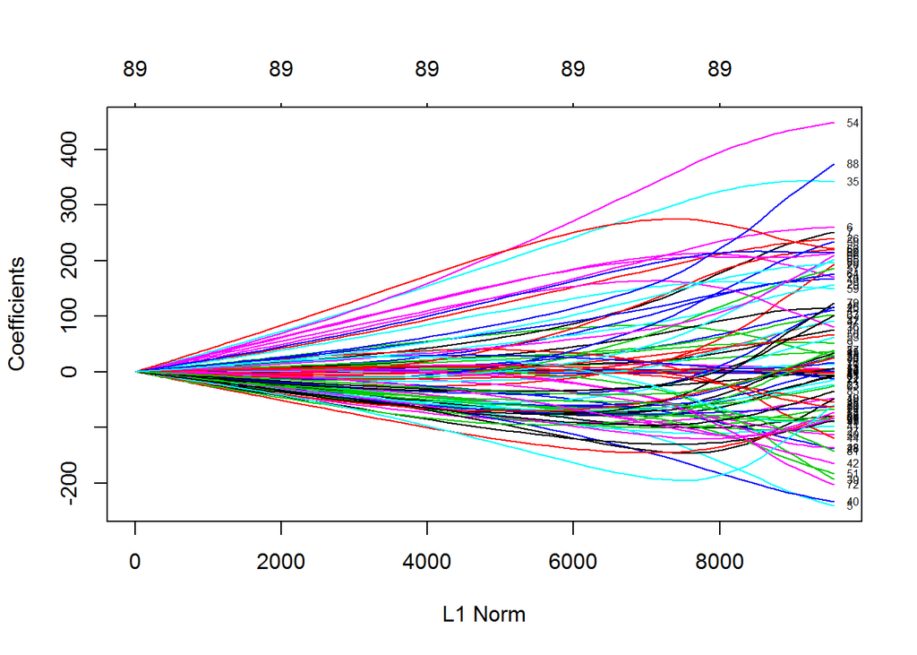

```r
plot(fit2,xvar="norm", label=TRUE)
```

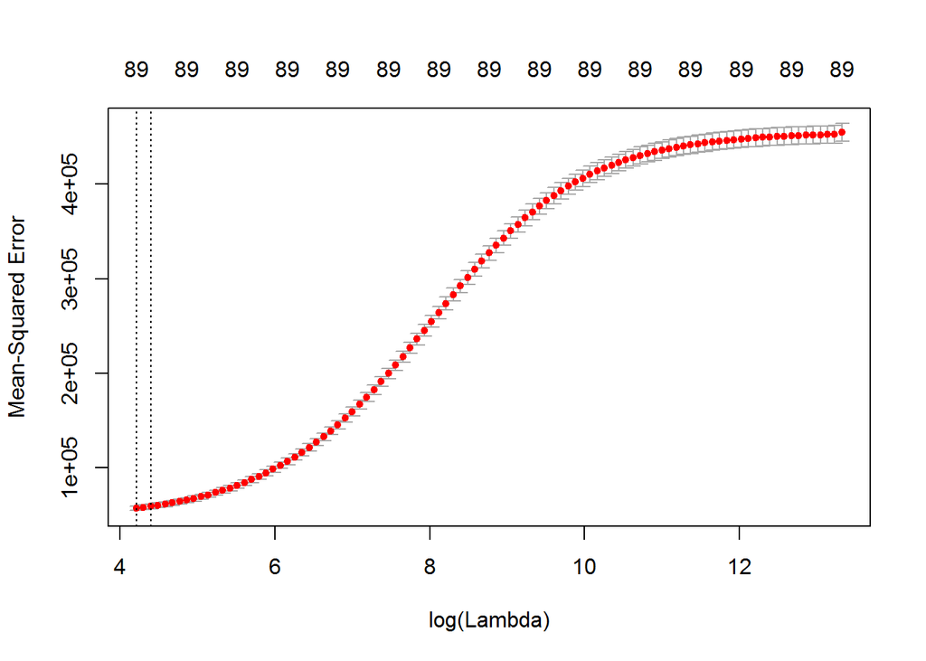

```r
## Model Selection

cv.ridge=cv.glmnet(Train_glm,y_train,alpha=0)
plot(cv.ridge)
```

```r
#coef(cv.ridge)
#cv.lasso$cvm

## lambda.min - value of lambda that gives minimum cvm - mean cross-validated error

cv.ridge$lambda.min
```

```
## [1] 67.35013
```

```r
## predict

fit_Ridge = glmnet(Train_glm,y_train,lambda=cv.ridge$lambda.min,alpha=0)

## Error Verification on Train

train_Ridge = regr.eval(y_train, predict(fit_Ridge,Train_glm))
train_Ridge
```

```
##          mae          mse         rmse         mape
## 1.418346e+02 5.653708e+04 2.377753e+02 1.616798e-01
```

```r
## Error Verification on Test

test_Ridge = regr.eval(y_test, predict(fit_Ridge,Test_glm))
test_Ridge
```

```
##          mae          mse         rmse         mape
## 1.472684e+02 6.219973e+04 2.493987e+02 1.640374e-01
```

Model (5)

## Elastic regression

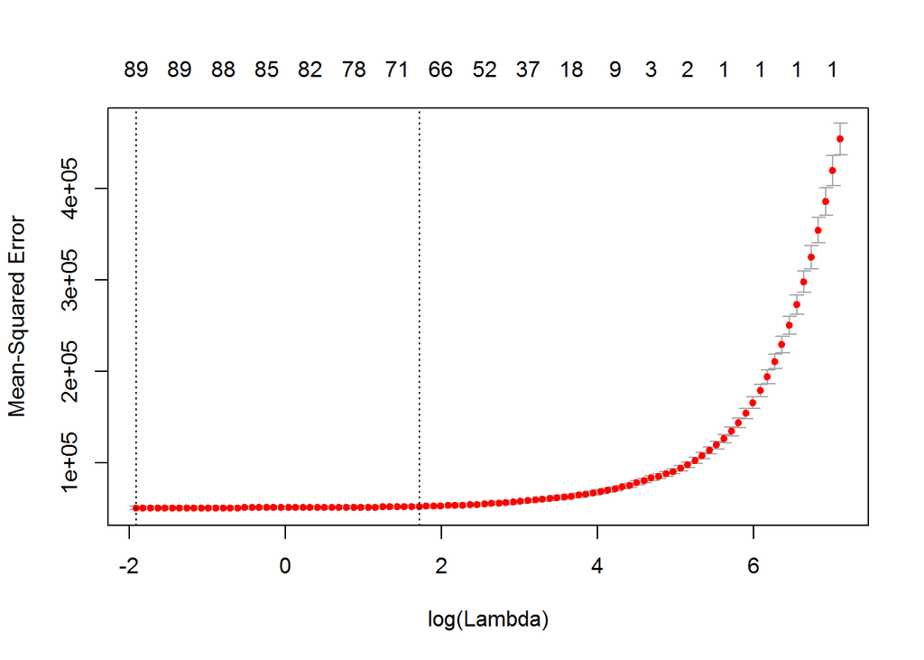

```r
# Elastic Net creates a regression model that is penalized with both the L1-norm
# and L2-norm. This has the effect of effectively shrinking coefficients (
# as in ridge regression) and setting some coefficients to zero (as in LASSO).


library(glmnet)
library(DMwR)

## Fit Model

cv.Elastic=cv.glmnet(Train_glm,y_train,alpha=0.5)

## Plots

plot(cv.Elastic)
```

```r
#coef(cv.Elastic)
#cv.Elastic$cvm

## lambda.min - value of lambda that gives minimum cvm - mean cross-validated error

cv.Elastic$lambda.min
```

```
## [1] 0.1478334
```

```r
## Predict

fit_Elastic = glmnet(Train_glm,y_train,lambda=cv.Elastic$lambda.min,alpha=0.5)

## Error Verification on Train

train_Elastic = regr.eval(y_train, predict(fit_Elastic,Train_glm))
train_Elastic
```

```
##          mae          mse         rmse         mape
## 1.318814e+02 5.023289e+04 2.241270e+02 1.474699e-01
```

```r
## Error Verification on Test

test_Elastic = regr.eval(y_test, predict(fit_Elastic,Test_glm))
test_Elastic
```

```
##          mae          mse         rmse         mape
## 1.371099e+02 5.553499e+04 2.356586e+02 1.492724e-01
```

Error tables for Linear, Ridge, Lasso and Elastic Regression

```r
finalerros <- data.frame(rbind(train_Lm,test_Lm,
                               train_Lasso,test_Lasso,
                               train_Ridge,test_Ridge,
                               train_Elastic,test_Elastic))
finalerros
```

```
##                    mae      mse     rmse      mape
## train_Lm      131.6923 50200.59 224.0549 0.1471939
## test_Lm       137.0007 55537.91 235.6648 0.1491166
## train_Lasso   131.8873 50234.55 224.1307 0.1474764
## test_Lasso    137.1158 55534.85 235.6583 0.1492800
## train_Ridge   141.8346 56537.08 237.7753 0.1616798
## test_Ridge    147.2684 62199.73 249.3987 0.1640374
## train_Elastic 131.8814 50232.89 224.1270 0.1474699
## test_Elastic  137.1099 55534.99 235.6586 0.1492724
```

Start Of CLUSTERING